# Second Hand Vehicle Market in India

## Research Question

Since I came to Penn State, I have learned a lot about other countries. However, I feel like I still haven’t learned anything about India yet. Therefore, combining with my interest in cars, I decided to analyze some second hand vehicle market data from India.

- What are the factors that are affecting the selling price of used cars in India?
- Are cars with automatic transmission generally more expensive than cars with manual transmission?(in my theory automatic transmission should be more expensive)
- Is the data from Indian market same as the US market?

```r
rm(list=ls())
library(readr)
library(DataComputing)
library(tidyverse)
library(party)
library(rpart)
library(rpart.plot)
```

## Data Access

```r
CAR <- read_csv("CAR DETAILS FROM CAR DEKHO.csv")
vehicles <- read_csv("vehicles.csv")
```

## Inspecting the initial data

```r
head(CAR,message=FALSE)
```

| name | year | selling_price | km_driven | fuel | seller_type | transmission | owner |
| --- | --- | --- | --- | --- | --- | --- | --- |
| Maruti 800 AC | 2007 | 60000 | 70000 | Petrol | Individual | Manual | First Owner |
| Maruti Wagon R LXI Minor | 2007 | 135000 | 50000 | Petrol | Individual | Manual | First Owner |
| Hyundai Verna 1.6 SX | 2012 | 600000 | 100000 | Diesel | Individual | Manual | First Owner |
| Datsun RediGO T Option | 2017 | 250000 | 46000 | Petrol | Individual | Manual | First Owner |
| Honda Amaze VX i-DTEC | 2014 | 450000 | 141000 | Diesel | Individual | Manual | Second Owner |
| Maruti Alto LX BSIII | 2007 | 140000 | 125000 | Petrol | Individual | Manual | First Owner |

```r
head(vehicles,message=FALSE)
```

| id | url | region | region_url | price | year | manufacturer | model | condition | cylinders | fuel | odometer | title_status | transmission | vin | drive | size | type | paint_color | image_url | description | county | state | lat | long |
| --- | --- | --- | --- | --- | --- | --- | --- | --- | --- | --- | --- | --- | --- | --- | --- | --- | --- | --- | --- | --- | --- | --- | --- | --- |
| 7184791621 | https://duluth.craigslist.org/ctd/d/duluth-2000-gmc-new-sierra-1500-ext-cab/7184791621.html | duluth / superior | https://duluth.craigslist.org | 6995 | 2000 | gmc | new sierra 1500 | excellent | 8 cylinders | gas | 167783 | clean | automatic | 1GTEK19T3YE366021 | 4wd | NA | NA | red | https://images.craigslist.org/00n0n_f06ykBMcdhK_0cU09G_600x450.jpg | 2000 *** GMC New Sierra 1500 Ext Cab 157.5 WB 4WD SL *** Drive it home today!Call (218) 729-7360 Luxury Imports Inc. 5471 Miller Trunk Highway, Hermantown, MN 55811Copy & Paste the URL belowto view mo… | NA | mn | 46.8433 | -92.2550 |
| 7184773187 | https://duluth.craigslist.org/cto/d/saginaw-2013-hyundai-sonata-gls/7184773187.html | duluth / superior | https://duluth.craigslist.org | 8750 | 2013 | hyundai | sonata | excellent | 4 cylinders | gas | 90821 | clean | automatic | NA | fwd | NA | NA | grey | https://images.craigslist.org/00d0d_kgZ6xoeRw2E_0CI0t2_600x450.jpg | For Sale: 2013 Hyundai Sonata GLS - $8750. One owner car. Majority highway miles. Set of snow tires and rims included. Call Bob at 218-4two8-749three. | NA | mn | 46.9074 | -92.4638 |
| 7193375964 | https://newhaven.craigslist.org/cto/d/stratford-2013-toyota-prius-2-wagon-4d/7193375964.html | new haven | https://newhaven.craigslist.org | 10900 | 2013 | toyota | prius | good | 4 cylinders | hybrid | 92800 | clean | automatic | NA | fwd | NA | NA | blue | https://images.craigslist.org/00d0d_3sHGxPbY2Ot_0t20t2_600x450.jpg | 2013 Prius V Model Two. One owner—must sell my well loved Prius. Moved to NYC and cannot keep my car. The 2013 Toyota Prius V is available in three trim levels: the Two, the Three and the Five Standar… | NA | ct | 41.1770 | -73.1336 |
| 7195108810 | https://albuquerque.craigslist.org/cto/d/albuquerque-mitsubishi-lancer-evolution/7195108810.html | albuquerque | https://albuquerque.craigslist.org | 12500 | 2003 | mitsubishi | lancer | good | 4 cylinders | gas | NA | clean | manual | NA | 4wd | mid-size | sedan | grey | https://images.craigslist.org/00m0m_4a8Pb6JbMGy_0CI0t2_600x450.jpg | 2003 Mitsubishi Lancer Evolution, silver. About 132,xxx mileage Bought the car as a project 2 years ago, became my daily car for the past 2 years. Am not sure what the previous owner did to it, so I b… | NA | nm | 35.1868 | -106.6650 |
| 7184712241 | https://duluth.craigslist.org/ctd/d/rush-city-2007-gmc-sierra-classic/7184712241.html | duluth / superior | https://duluth.craigslist.org | 16995 | 2007 | gmc | sierra classic 2500hd | good | 8 cylinders | diesel | 254217 | clean | automatic | 1GTHK23D57F102022 | 4wd | full-size | truck | white | https://images.craigslist.org/01414_g093aPtSMWU_0cU09G_600x450.jpg | **Bad Credit, No Credit... No Problem!**2007 GMC Sierra Classic 2500HD SLT Crew Cab 4WD - $16,995 Year: 2007 Make:GMC Model:Sierra Classic 2500HD Trim:SLT Crew Cab 4WD Mileage:254,217 Stock #:254217 V… | NA | mn | 45.6836 | -92.9648 |
| 7184711787 | https://duluth.craigslist.org/ctd/d/rush-city-2012-ford-150-xlt-supercrew/7184711787.html | duluth / superior | https://duluth.craigslist.org | 13995 | 2012 | ford | f-150 | good | 6 cylinders | gas | 188406 | clean | automatic | 1FTFW1ET4CFC98801 | 4wd | full-size | truck | grey | https://images.craigslist.org/00W0W_io2cwEVtyh7_0cU09G_600x450.jpg | **Bad Credit, No Credit... No Problem!**2012 Ford F-150 XLT SuperCrew 6.5-ft. Bed 4WD - $13,995 Year: 2012 Make:Ford Model:F-150 Trim:XLT SuperCrew 6.5-ft. Bed 4WD Mileage:188,406 Stock #:188406 VIN:1… | NA | mn | 45.6836 | -92.9648 |

```r
nrow(CAR)
```

```
[1] 4340
```

```r
nrow(vehicles)
```

```
[1] 423857
```

```r
ncol(CAR)
```

```
[1] 8
```

```r
ncol(vehicles)
```

```
[1] 25
```

8 variables and 4340 observations in CAR table, 25 variables and 423857 observations in vehicles table.

## Data Wrangling

```r
Without_Name_IN <- # data wrangling the table for used car market data from India
  CAR %>%
  group_by(km_driven,fuel,transmission) %>% # factors that I would like to explore with graph
  summarise(price=mean(selling_price), total=n())%>%
  spread(key=fuel, value=total, fill=0) %>% # spread the fuel category to make the comparison more effective
  rename(diesel=Diesel, electric=Electric, Transmission=transmission) %>% # so that two tables can match
  mutate(country="India") # identify the country

Without_Name_IN$transmission=tolower(Without_Name_IN$Transmission)# in order to later match with the US data

Without_Name_IN
```

| km_driven | Transmission | price | CNG | diesel | electric | LPG | Petrol | country | transmission |
| --- | --- | --- | --- | --- | --- | --- | --- | --- | --- |
| 1 | Manual | 250000.00 | 0 | 1 | 0 | 0 | 0 | India | manual |
| 101 | Manual | 635000.00 | 0 | 0 | 0 | 0 | 1 | India | manual |
| 101 | Manual | 892000.00 | 0 | 2 | 0 | 0 | 0 | India | manual |
| 1000 | Manual | 476214.29 | 0 | 14 | 0 | 0 | 0 | India | manual |
| 1000 | Manual | 651250.00 | 0 | 0 | 0 | 0 | 4 | India | manual |
| 1001 | Manual | 662500.00 | 0 | 2 | 0 | 0 | 0 | India | manual |
| 1010 | Manual | 928399.60 | 0 | 0 | 0 | 0 | 5 | India | manual |
| 1010 | Manual | 1332500.00 | 0 | 2 | 0 | 0 | 0 | India | manual |
| 1100 | Automatic | 600000.00 | 0 | 0 | 0 | 0 | 1 | India | automatic |
| 1100 | Manual | 812500.00 | 0 | 0 | 0 | 0 | 4 | India | manual |

[output cut: 990 more lines]

```r
Without_Name_US <- # data wrangling the table for used car market data from US
  vehicles %>%
  filter(!is.na(price),!is.na(transmission),!is.na(fuel),!is.na(odometer),odometer != 0) %>% # filter our the NA values and new cars (since we are comparing the used cars)
  mutate(km_driven=odometer) %>% # match the variable name from India
  group_by(km_driven,price,transmission,fuel) %>%
  summarise(total=n()) %>%
   spread(key=fuel, value=total, fill=0)%>%
  mutate(country="America")

Without_Name_US
```

| km_driven | price | transmission | diesel | electric | gas | hybrid | other | country |
| --- | --- | --- | --- | --- | --- | --- | --- | --- |
| 1 | 0 | automatic | 20 | 2 | 51 | 0 | 1 | America |
| 1 | 0 | other | 0 | 0 | 1 | 0 | 1 | America |
| 1 | 1 | automatic | 0 | 0 | 39 | 0 | 0 | America |
| 1 | 1 | other | 0 | 0 | 1 | 0 | 0 | America |
| 1 | 2 | automatic | 0 | 0 | 1 | 0 | 0 | America |
| 1 | 99 | automatic | 0 | 0 | 0 | 0 | 3 | America |
| 1 | 99 | other | 0 | 0 | 0 | 0 | 1 | America |
| 1 | 400 | other | 0 | 0 | 0 | 0 | 1 | America |
| 1 | 650 | automatic | 0 | 0 | 1 | 0 | 0 | America |
| 1 | 999 | automatic | 0 | 0 | 1 | 0 | 0 | America |

[output cut: 990 more lines]

```r
Combined_Table <-
  Without_Name_IN %>%
  mutate(price=price*0.014)%>% #change currency unit to usd
 full_join(Without_Name_US)


Combined_Table
```

| km_driven | Transmission | price | CNG | diesel | electric | LPG | Petrol | country | transmission | gas | hybrid | other |
| --- | --- | --- | --- | --- | --- | --- | --- | --- | --- | --- | --- | --- |
| 1 | Manual | 3500.000 | 0 | 1 | 0 | 0 | 0 | India | manual | NA | NA | NA |
| 101 | Manual | 8890.000 | 0 | 0 | 0 | 0 | 1 | India | manual | NA | NA | NA |
| 101 | Manual | 12488.000 | 0 | 2 | 0 | 0 | 0 | India | manual | NA | NA | NA |
| 1000 | Manual | 6667.000 | 0 | 14 | 0 | 0 | 0 | India | manual | NA | NA | NA |
| 1000 | Manual | 9117.500 | 0 | 0 | 0 | 0 | 4 | India | manual | NA | NA | NA |
| 1001 | Manual | 9275.000 | 0 | 2 | 0 | 0 | 0 | India | manual | NA | NA | NA |
| 1010 | Manual | 12997.594 | 0 | 0 | 0 | 0 | 5 | India | manual | NA | NA | NA |
| 1010 | Manual | 18655.000 | 0 | 2 | 0 | 0 | 0 | India | manual | NA | NA | NA |
| 1100 | Automatic | 8400.000 | 0 | 0 | 0 | 0 | 1 | India | automatic | NA | NA | NA |
| 1100 | Manual | 11375.000 | 0 | 0 | 0 | 0 | 4 | India | manual | NA | NA | NA |

[output cut: 990 more lines]

```r
logfit<- lm(log(selling_price)~transmission+year+km_driven+fuel+seller_type+owner, data = CAR) # try to figure out the relationship between selling price and other variables. Log transformation is applied in order to met the model assumptions
summary(logfit)
```

```
Call:
lm(formula = log(selling_price) ~ transmission + year + km_driven +
    fuel + seller_type + owner, data = CAR)

Residuals:
     Min       1Q   Median       3Q      Max
-1.76930 -0.30211 -0.00082  0.28965  2.34532

Coefficients:
                              Estimate Std. Error t value Pr(>|t|)
(Intercept)                 -2.138e+02  4.279e+00 -49.968  < 2e-16 ***
transmissionManual          -8.025e-01  2.433e-02 -32.984  < 2e-16 ***
year                         1.128e-01  2.120e-03  53.216  < 2e-16 ***
km_driven                   -3.902e-07  1.860e-07  -2.098 0.035950 *
fuelDiesel                   5.839e-01  7.535e-02   7.749 1.14e-14 ***
fuelElectric                 1.983e-01  4.779e-01   0.415 0.678172
fuelLPG                     -5.011e-02  1.234e-01  -0.406 0.684779
fuelPetrol                   7.311e-02  7.541e-02   0.970 0.332323
seller_typeIndividual       -1.569e-01  1.821e-02  -8.616  < 2e-16 ***
seller_typeTrustmark Dealer  3.085e-01  4.914e-02   6.278 3.76e-10 ***
ownerFourth & Above Owner   -1.398e-01  5.510e-02  -2.537 0.011227 *
ownerSecond Owner           -4.624e-02  1.843e-02  -2.509 0.012154 *
ownerTest Drive Car          1.659e-01  1.159e-01   1.432 0.152147
ownerThird Owner            -1.164e-01  3.071e-02  -3.792 0.000152 ***
---
Signif. codes:  0 ‘***’ 0.001 ‘**’ 0.01 ‘*’ 0.05 ‘.’ 0.1 ‘ ’ 1

Residual standard error: 0.4709 on 4326 degrees of freedom
Multiple R-squared:  0.6861,    Adjusted R-squared:  0.6852
F-statistic: 727.5 on 13 and 4326 DF,  p-value: < 2.2e-16
```

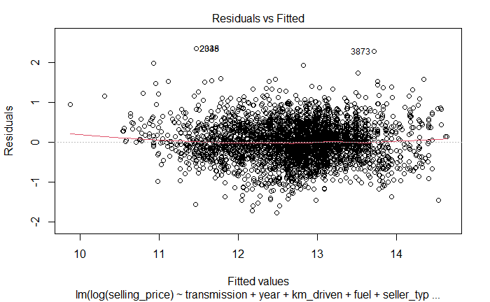

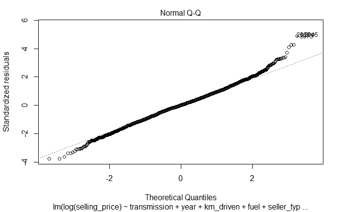

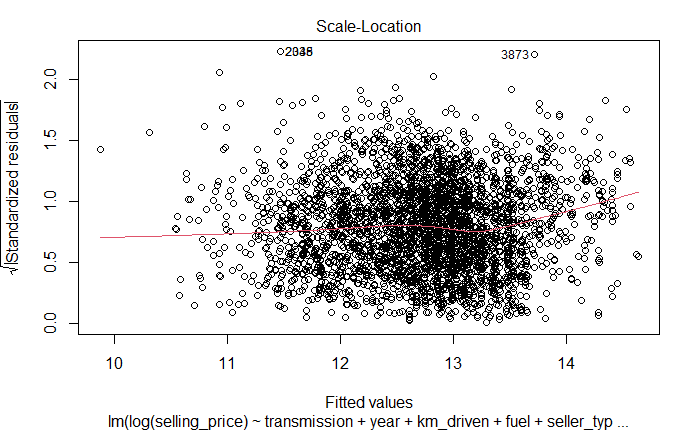

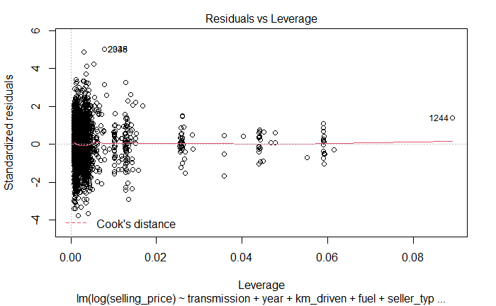

```r
plot(logfit) # check the model assumption
```

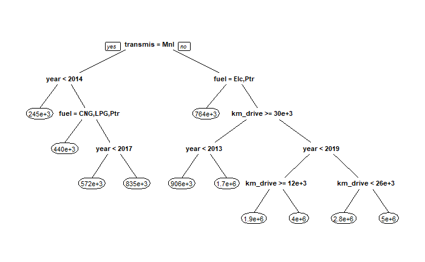

```r
treemod <- rpart(selling_price~transmission+year+fuel+km_driven, data=CAR)
prp(treemod)
```

Key Takeaways from the table

- Transmission type, fuel type, number of previous owners, seller type, year of the car, and km_driven are significant predictors of selling price for the used car in Indian market.
- Each condition of the car can lead to different price.

# Data Visualization

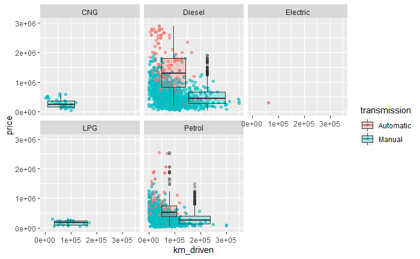

```r
CAR %>%
  ggplot(aes(x=km_driven, y=selling_price, fill=transmission)) +
  facet_wrap(fuel~.) +
  geom_point(aes(color=transmission), alpha=0.6)+
  geom_boxplot(alpha=0.3)+
  ylab("price") +
  xlim(0,350000)+ # majority of cars have millage bellow 350000, in order to reduce the effect of outliers, the max is set to 350000.
  ylim(0,3000000)# majority of cars have selling price bellow 3000000, in order to reduce the effect of outliers, the max is set to 3000000.
```

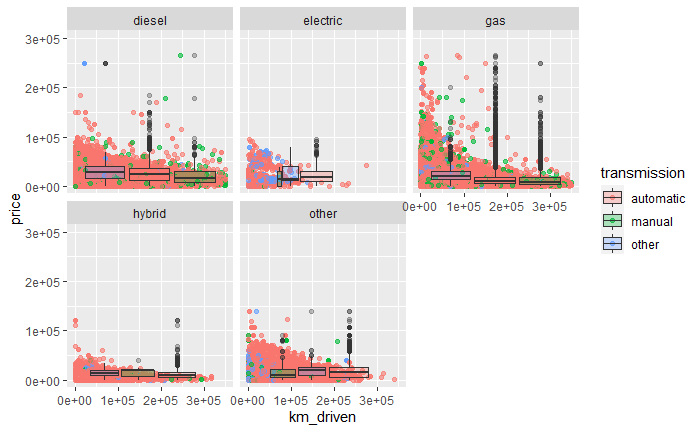

```r
vehicles %>%
  filter(!is.na(price),!is.na(transmission),!is.na(fuel),!is.na(odometer),odometer != 0) %>%
  ggplot(aes(x=odometer,y=price,fill=transmission)) +
  facet_wrap(fuel~.) +
  geom_point(aes(color=transmission),alpha=0.6)+
  geom_boxplot(alpha=0.3)+
  xlab("km_driven") +
  xlim(0,350000)+
  ylim(0,300000)
```

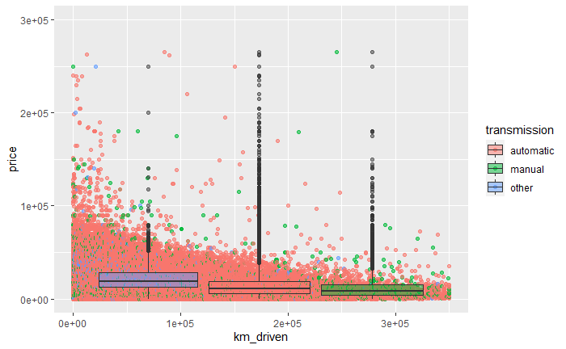

```r
Combined_Table %>%
  ggplot(aes(x=km_driven,y=price,fill=transmission)) +
  geom_point(aes(color=transmission),alpha=0.6)+
  geom_boxplot(alpha=0.5)+
  xlim(0,350000)+
  ylim(0,300000)
```

- The plot is about the combined table for both India and America. From the graph, there is a negative linear relationship between millage and selling price.
- The auto transmission still has slightly higher median price than manual transmission even though the have similar range.

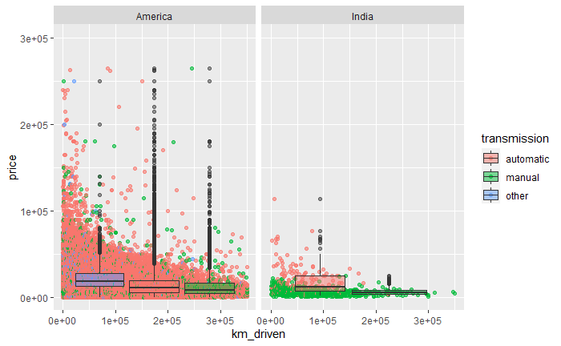

```r
Combined_Table %>%
  ggplot(aes(x=km_driven,y=price,fill=transmission)) +
  geom_point(aes(color=transmission),alpha=0.6)+
  geom_boxplot(alpha=0.5)+
  facet_wrap(country~.)+
  xlim(0,350000)+
  ylim(0,300000)
```

- In India, the median selling price for auto transmission is much higher than manual transmission. Auto transmission also have wider price range.
- In America, the difference in median selling price between auto and manual transmission is not obvious. However, since there is a “other” type of transmission, after research, still belongs to the broader category of auto transmission. Therefore, auto transmission still have higher median selling price.

## Challenge

- My biggest challenge is when trying to combine two tables, the India table has capital cased transmission (Automatic/Manual) while the US table has lower cased (automatic/manual). In order to effectively compare two data sets, I took hours of work to figure this way - lower case the entire column instead of matching. I also had to rename some of my variables so that R would treat those as same category.

## Key Takeaway

- According to the data from India, since the p-value is less than 0.05, we can conclude that transmission, fuel, km_driven, year, seller type, and number of owners are significant predictors of selling price in the India market.
- For India market, the selling price for auto transmission is significantly higher than manual transmission.
- In comparison, the selling price for auto transmission and manual transmission are about the same in the US.
- The Indian market favors automatic transmission while the Us market is indifferent.

## Github repo

[Click here](https://sihan-wu.github.io/Fianl-Proj/)